# Review problems

Michael Chow

# Data Structures and Types

1. Read in `dat1.Rdata`, which contains two columns of numbers (`a` and `b`). Add column `a` to `b`.

```r
load('dat1.Rdata')    # load variable named dat
dat                   # print it out
```

```
##     a  b
## 1   1 11
## 2   2 12
## 3   3 13
## 4   4 14
## 5   5 15
## 6   6 16
## 7   7 17
## 8   8 18
## 9   9 19
## 10 10 20
```

```r
# add column a and b

as.integer(dat$a) + dat$b
```

```
##  [1] 12 14 16 18 20 22 24 26 28 30
```

2. How did the `data.frame` decide the names of its columns? How could you have it name them `a` and `b` without adding a new line of code?

```r
dat <- data.frame(1:10, 11:20)

names(dat) <- c('a','b')
```

3. Write the `data.frame` below to a csv file using `write.csv`. Then, read it back in using `read.csv`. What do you expect the column name to be when you read the data back in? Test your answer. What does this say about how R reads in data.frames?

```r
# new data frame
d <- data.frame(1:3)
names(d) <- "a 1"
names(d)
```

```
## [1] "a 1"
```

```r
# write to csv below
write.csv(d, file='new_data.csv')

# read that csv in below
newdat <- read.csv('new_data.csv')

# what do you think the name of the column will be? Check it.
names(newdat)
```

```
## [1] "X"   "a.1"
```

```r
# what about the data frame below?
data.frame("a 1"=1:3, "b"=2)
```

```
##   a.1 b
## 1   1 2
## 2   2 2
## 3   3 2
```

4. Without using the dollar sign (e.g. `dat$`) or blocks (e.g. `dat[]`), do the following..
- paste columns `a` and `b` together
- paste those columns again, except now create a third column named `c` with the results
- do the same as above, but now add a fourth column as well (with anything you want)
- get all rows where `b` is greater than 13

```r
dat <- data.frame(a = 1:10, b = 11:20)

# paste a and b together
with(dat, paste(a, b))
```

```
##  [1] "1 11"  "2 12"  "3 13"  "4 14"  "5 15"  "6 16"  "7 17"  "8 18"
##  [9] "9 19"  "10 20"
```

```r
# make third column c
transform(dat, c = paste(a,b))
```

```
##     a  b     c
## 1   1 11  1 11
## 2   2 12  2 12
## 3   3 13  3 13
## 4   4 14  4 14
## 5   5 15  5 15
## 6   6 16  6 16
## 7   7 17  7 17
## 8   8 18  8 18
## 9   9 19  9 19
## 10 10 20 10 20
```

```r
# make third and fourth columns
transform(dat, c = paste(a,b), d = 1)
```

```
##     a  b     c d
## 1   1 11  1 11 1
## 2   2 12  2 12 1
## 3   3 13  3 13 1
## 4   4 14  4 14 1
## 5   5 15  5 15 1
## 6   6 16  6 16 1
## 7   7 17  7 17 1
## 8   8 18  8 18 1
## 9   9 19  9 19 1
## 10 10 20 10 20 1
```

```r
# get rows where b is greater than 13
subset(dat, b > 13)
```

```
##     a  b
## 4   4 14
## 5   5 15
## 6   6 16
## 7   7 17
## 8   8 18
## 9   9 19
## 10 10 20
```

5. We want the vector `arr` below to sum to 5.
- index `arr` to remove the values that are screwing up `sum` so that is sums correctly
- try passing the `na.rm` argument to the sum function

```r
arr <- rep(c(1, NA), 5)

arr
```

```
##  [1]  1 NA  1 NA  1 NA  1 NA  1 NA
```

```r
sum(arr)     # should sum to 5
```

```
## [1] NA
```

```r
# subset arr below so that sum is correct
sum(arr[!is.na(arr)])
```

```
## [1] 5
```

```r
# try using na.rm argument of sum function
sum(arr, na.rm = TRUE)
```

```
## [1] 5
```

6. We want the sum below to be 8. Re-assign two values of `a` to make this happen. What do you think will happen when you use the `na.rm` argument? Test your guess.

```r
a <- 3:8 / rep(-1:1, each=2)

# uncomment and modify the line below
a[is.infinite(a)] <- 0
sum(a)
```

```
## [1] 8
```

```r
# test na.rm argument below
sum(a, na.rm = TRUE)
```

```
## [1] 8
```

7. Array indexing and counting.
- Assign the indices in the array that correspond to “princeton” to the variable `indx`. Then, use this variable to get the values of “princeton” from the array.
- Count the number of entries for each school

```r
arr <- sample(c('princeton', 'yale'), 10, replace=TRUE)

# assign indices to variable indx
indx <- which(arr == "princeton")


# get values of "princeton"
arr[indx]
```

```
## [1] "princeton" "princeton" "princeton" "princeton" "princeton" "princeton"
```

```r
table(arr)
```

```
## arr
## princeton      yale
##         6         4
```

8. Count the number of entries for each combination of school and gender (i.e. you will have 4 counts)

```r
dat <- data.frame(school=rep(c('princeton', 'yale', 'yale'), each=3),
           gender=rep(c('m', 'm', 'f'), 3))

table(dat[c('school', 'gender')])
```

```
##            gender
## school      f m
##   princeton 1 2
##   yale      2 4
```

# Functions

1. Note `runif(1)` yields a random value between 0 and 1.
- pass `runif(1)` to a function that will repeat the value it produces 10 times
- pass `runif(1)` to a function that will repeat `runif` to produce 10 random values

```r
# replace f with the correct function (you may need to give additional arguments)
rep(runif(1), 10)
```

```
##  [1] 0.9084271 0.9084271 0.9084271 0.9084271 0.9084271 0.9084271 0.9084271
##  [8] 0.9084271 0.9084271 0.9084271
```

```r
# replace f for the second pard
replicate(10, runif(1))
```

```
##  [1] 0.2882942 0.8536096 0.3532969 0.8694944 0.9941380 0.8747754 0.6076906
##  [8] 0.7385788 0.2234439 0.3196310
```

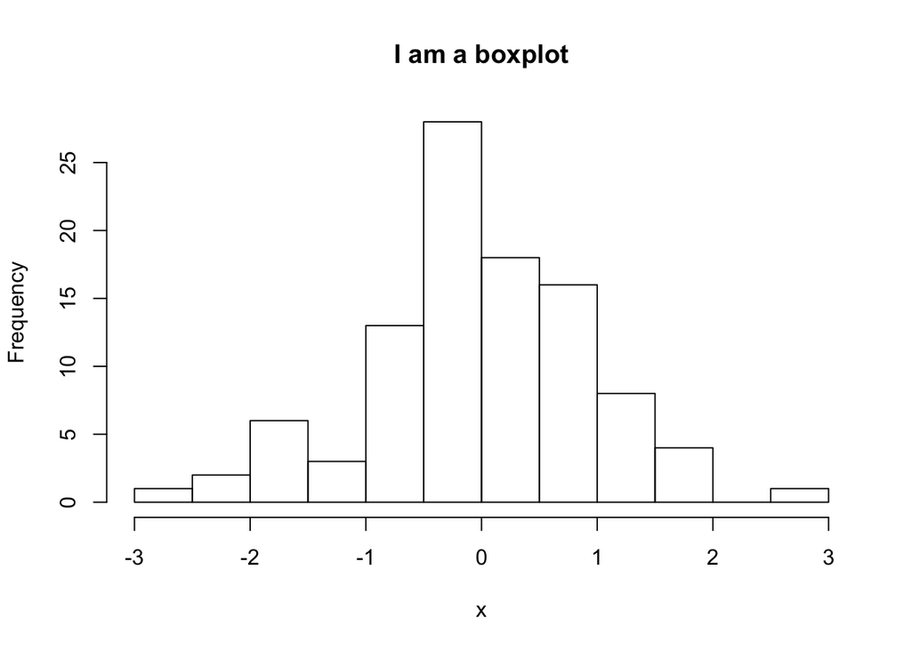

```r
makeBoxplot <- function(x, ...){
  hist(x, ...)
}

makeBoxplot(rnorm(100), main="I am a boxplot")
```

3. In many cases, researchers will use a summary measure called standard error, which we will define as the standard deviation (`sd`), divided by the square root of the number of observations in a sample. Write a function, `se`, that returns the standard error of a vector of sample data. Modify the function so that optional arguments can be passed to the `sd` function within `se`.

```r
# use sd, length, and sqrt functions
se <- function(x, ...) {
  # complete this function
  sd(x, ...) / sqrt(length(x))
}
```

4. `tapply` is a function that breaks up a vector into groups, and applies a function to each group. You use it like `tapply(value_vector, group_vector, function, addition_arguments)`. Use the `se` function you created above to get the standard error of the values for each group. Be sure to pass the `na.rm` using `tapply(value_vector, group_vector, function, na.rm=TRUE)` argument to se.

```r
dat <- data.frame(value = c(rnorm(30, 10), rnorm(30), NA),
                  group = c(rep(c('A', 'B'), each=30), NA))

# fill in tapply function
tapply(dat$value, dat$group, se, na.rm=TRUE)
```

```
##         A         B
## 0.2031309 0.2070784
```

# Control Flow

1. For each number in the array below
- if it is even, then print the square
- if it is odd, then print the square-root

```r
arr <- 1:10
# put loop here

for (i in arr) {
  if (i %% 2 == 0) print(i^2)
  else print(sqrt(i))
}
```

```
## [1] 1
## [1] 4
## [1] 1.732051
## [1] 16
## [1] 2.236068
## [1] 36
## [1] 2.645751
## [1] 64
## [1] 3
## [1] 100
```

2. Solve the above problem without using a for loop

```r
arr <- 1:10

# put solution here
```

3. [Fibonnaci Sequence](https://en.wikipedia.org/wiki/Fibonacci_number). Create a Fibonnaci Sequence that goes to 15 entries. By either..
- creating an array of 15 zeroes, looping over it, and assigning the proper values to it
- using the repeat statement rather than a for loop

# Errors

1. What does this error mean?

```r
a <- 3
x <- 5

eval(rm(list=tolower(LETTERS[20+4])))
```

```r
a + x
```

```
## Error in eval(expr, envir, enclos): object 'x' not found
```

2. What went wrong here? Could you create a similar error with another function?

```r
# What likely went wrong here?
dat <- read.csv('dat2.csv')
newdat <- subset(dat, a < 4)

# Similar error
```

[output not shown]

3. What does this error mean?

```r
load('dat3.Rdata')

df$b + 4
```

```
## Error in df$b: object of type 'closure' is not subsettable
```